# Analysis of Severe Weather Events in the U.S. (1950-2011): Health and Economic Impacts

## Results

### Health Impacts of Weather Events

The following figure shows the top 10 severe weather events that have the highest combined number of fatalities and injuries across the United States from 1950 to 2011. Tornadoes appear to be the most harmful event in terms of population health.

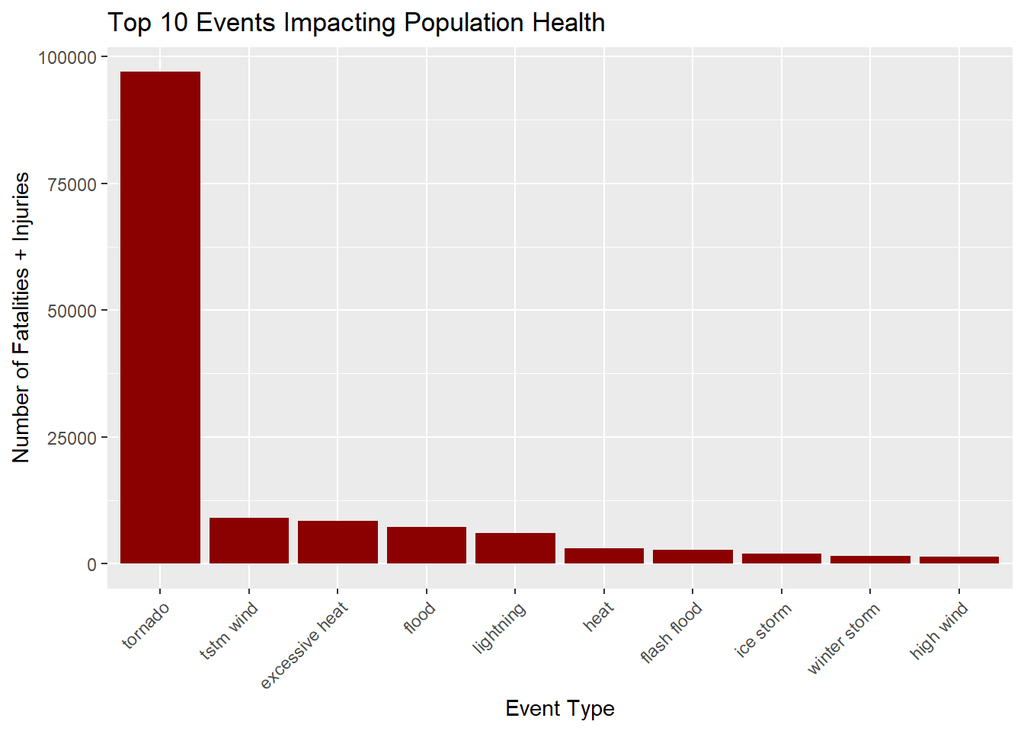

```r
library(ggplot2)
# Plotting the top events impacting health
ggplot(top_health_events, aes(x = reorder(EVTYPE, -(total_fatalities + total_injuries)),
                              y = total_fatalities + total_injuries)) +
  geom_bar(stat = "identity", fill = "darkred") +
  labs(title = "Top 10 Events Impacting Population Health",
       x = "Event Type", y = "Number of Fatalities + Injuries") +
  theme(axis.text.x = element_text(angle = 45, hjust = 1))
```

### Economic Impacts of Weather Events

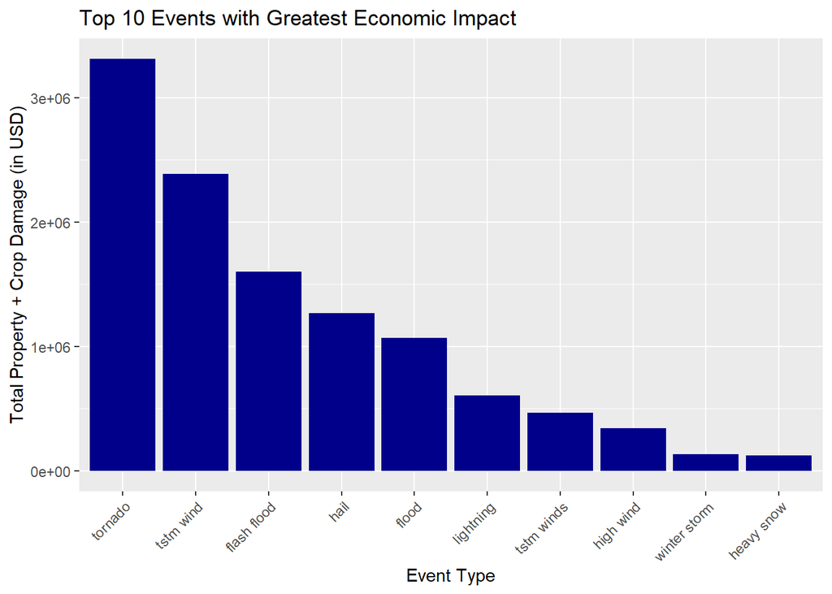

```r
# Plotting the top events with economic impact
ggplot(top_economic_events, aes(x = reorder(EVTYPE, -total_economic_dmg),
                                y = total_economic_dmg)) +
  geom_bar(stat = "identity", fill = "darkblue") +
  labs(title = "Top 10 Events with Greatest Economic Impact",
       x = "Event Type", y = "Total Property + Crop Damage (in USD)") +
  theme(axis.text.x = element_text(angle = 45, hjust = 1))
```

### Conclusion

Health Impacts: Tornadoes have by far the most devastating impact on population health, with the highest number of fatalities and injuries over the 61-year period. Other harmful events include excessive heat, and Thunderstorm winds.